# Data Pre-Processing

Goh Jie Xin

10/4/2021

# Libraries

```r
library(dplyr)
library(DataExplorer)
library(mice)
library(VIM)
library(missForest)
library(caret)
```

# Read Data

```r
# Convert "NA" or Blanks to NA
# Convert String Type to Factor
df <- read.csv('aug_train.csv', header = T, na.strings=c("NA","NaN", ""), stringsAsFactors=T)

head(df,5)
```

```
##   enrollee_id     city city_development_index gender     relevent_experience
## 1        8949 city_103                  0.920   Male Has relevent experience
## 2       29725  city_40                  0.776   Male  No relevent experience
## 3       11561  city_21                  0.624   <NA>  No relevent experience
## 4       33241 city_115                  0.789   <NA>  No relevent experience
## 5         666 city_162                  0.767   Male Has relevent experience
##   enrolled_university education_level major_discipline experience company_size
## 1       no_enrollment        Graduate             STEM        >20         <NA>
## 2       no_enrollment        Graduate             STEM         15        50-99
## 3    Full time course        Graduate             STEM          5         <NA>
## 4                <NA>        Graduate  Business Degree         <1         <NA>
## 5       no_enrollment         Masters             STEM        >20        50-99
##     company_type last_new_job training_hours target
## 1           <NA>            1             36      1
## 2        Pvt Ltd           >4             47      0
## 3           <NA>        never             83      0
## 4        Pvt Ltd        never             52      1
## 5 Funded Startup            4              8      0
```

```r
# If the df has blanks, fill in with NA
df <- mutate_all(df, na_if, "")
```

# Remove unrelated column

1. Column enrollee_id does not give any useful information, so we can delete the column.
2. Column city and city_development_index is correlated. Same city will have same city_development_index, so we can remove column city (as it has too many categories).

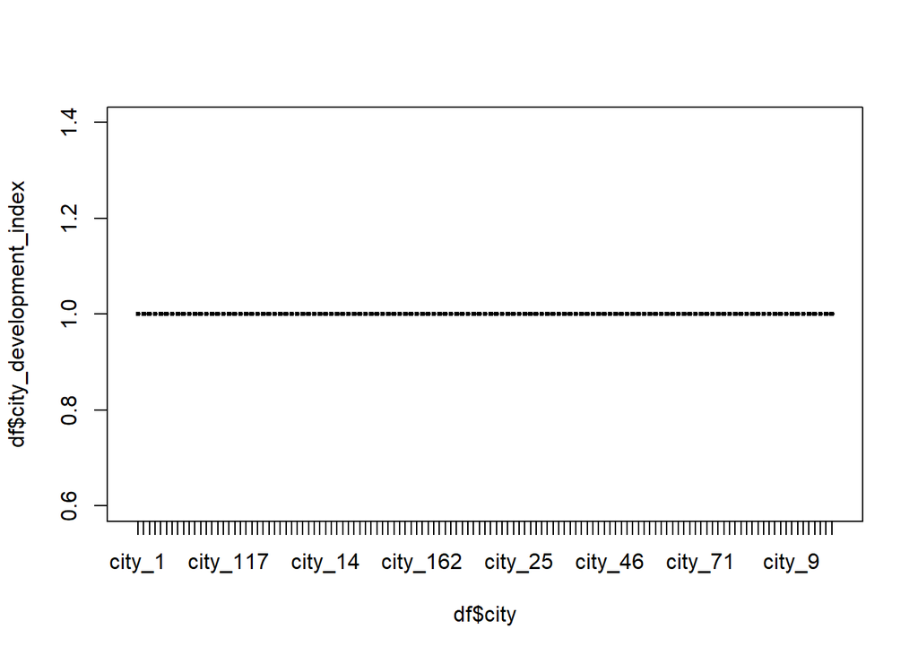

```r
# Aggregate function (Group by and Count Unique)
plot(aggregate( df$city_development_index~df$city,df, function(x) length(unique(x))))
```

```r
# Remove columns
df$enrollee_id <- NULL
df$city <- NULL
```

# Convert Column Format

1. Column target is in num type. We need to convert to factor type.

```r
# Convert column format to factor
df$target <- as.factor(df$target)
```

2. Column experience is factor type. We can convert to num type but before convert need to replace: “<1” –> “0” –> 0 “>20” –> “21” –> 21

```r
print("Before conversion: ")
```

```
## [1] "Before conversion: "
```

```r
levels(df$experience)
```

```
##  [1] "<1"  ">20" "1"   "10"  "11"  "12"  "13"  "14"  "15"  "16"  "17"  "18"
## [13] "19"  "2"   "20"  "3"   "4"   "5"   "6"   "7"   "8"   "9"
```

```r
levels(df$experience) <- c(levels(df$experience),"0","21")
df$experience[df$experience=="<1"]  <- "0"
df$experience[df$experience==">20"]  <- "21"
# Convert from factor to numeric
df$experience <- as.numeric(as.character(df$experience))
print("After conversion: ")
```

```
## [1] "After conversion: "
```

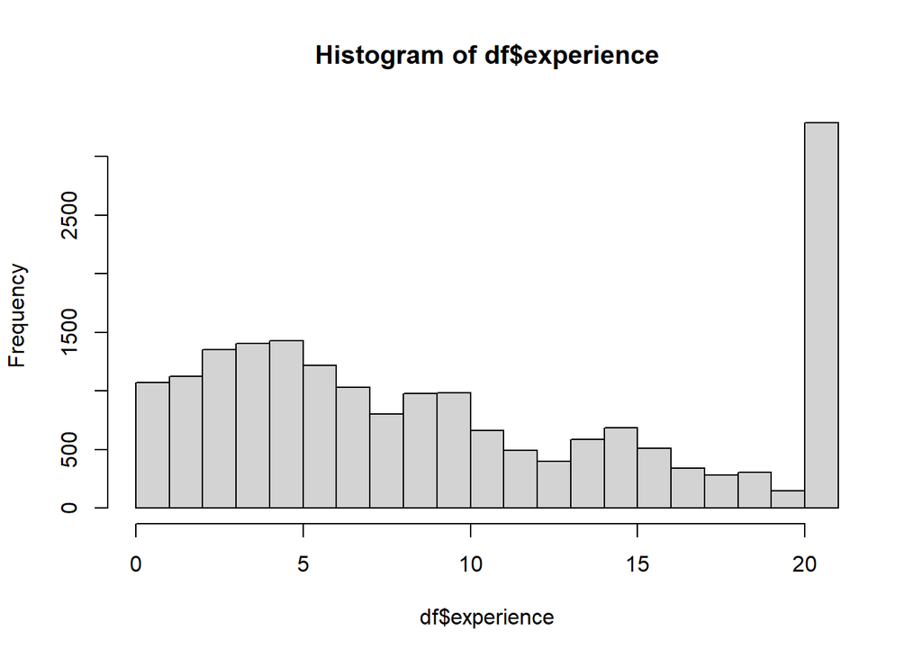

```r
hist(df$experience)
```

3. Column last_new_job is factor type. We can convert to num type but before convert need to replace: “>4” –> “5” “never” –> “0”

```r
print("Before conversion: ")
```

```
## [1] "Before conversion: "
```

```r
levels(df$last_new_job)
```

```
## [1] ">4"    "1"     "2"     "3"     "4"     "never"
```

```r
levels(df$last_new_job) <- c(levels(df$last_new_job),"5","0")
df$last_new_job[df$last_new_job==">4"]  <- "5"
df$last_new_job[df$last_new_job=="never"]  <- "0"
# COnvert from factor to numeric
df$last_new_job <- as.numeric(as.character(df$last_new_job))
print("After conversion: ")
```

```
## [1] "After conversion: "
```

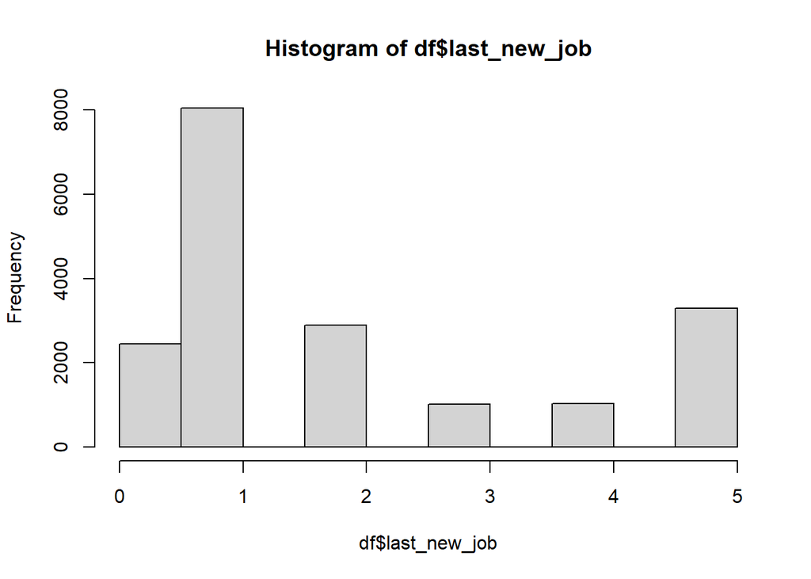

```r
hist(df$last_new_job)
```

```r
write.csv(df, file = "aug_train2.csv")
```

# Handling Missing Values

Check if there is any missing values.

```r
# View missing values
colSums(is.na(df))
```

```
## city_development_index                 gender    relevent_experience
##                      0                   4508                      0
##    enrolled_university        education_level       major_discipline
##                    386                    460                   2813
##             experience           company_size           company_type
##                     65                   5938                   6140
##           last_new_job         training_hours                 target
##                    423                      0                      0
```

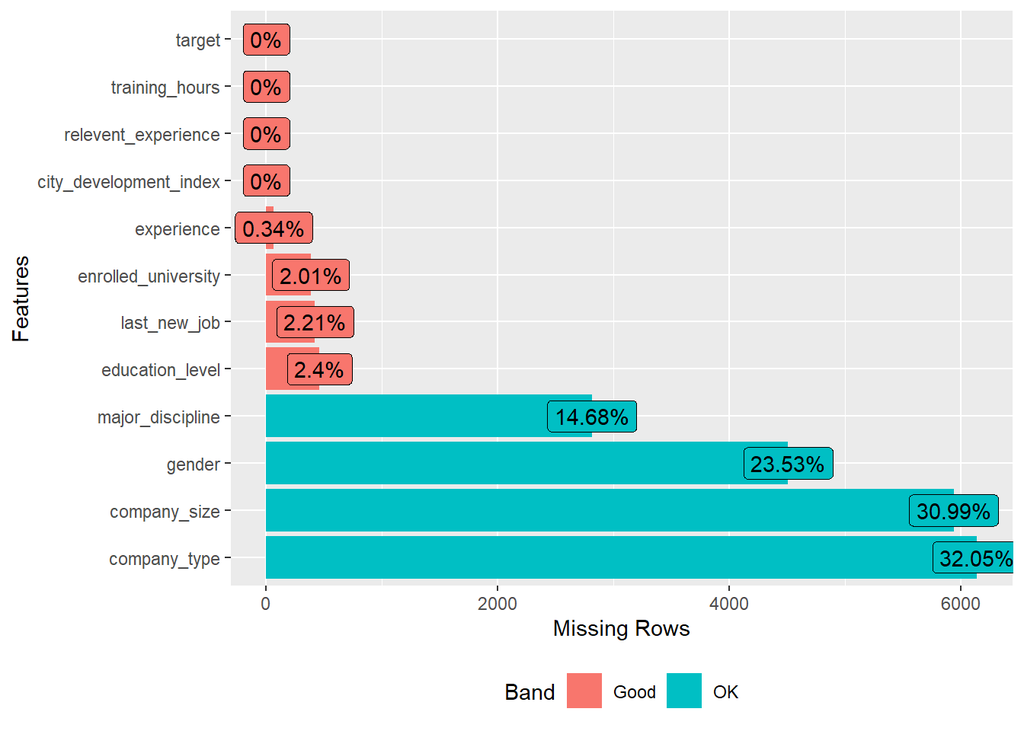

```r
plot_missing(df)
```

There are 8 columns with missing values. Instead of removing those columns, we will try to fill in the missing values with different method.

## Method 1 - Imputation

1. Continuous column - fill NA by mean. na.rm = True : ignore NA when computing mean
2. Factor column - fill NA by mode

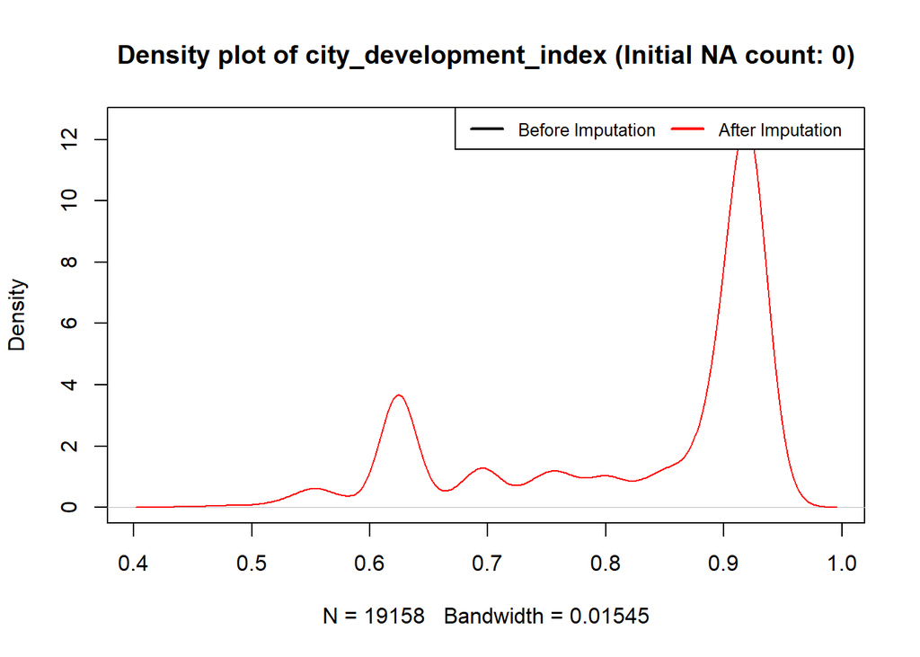

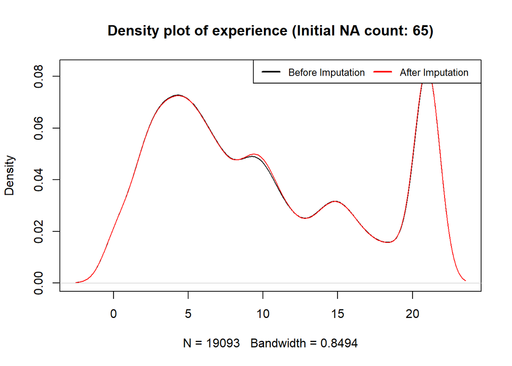

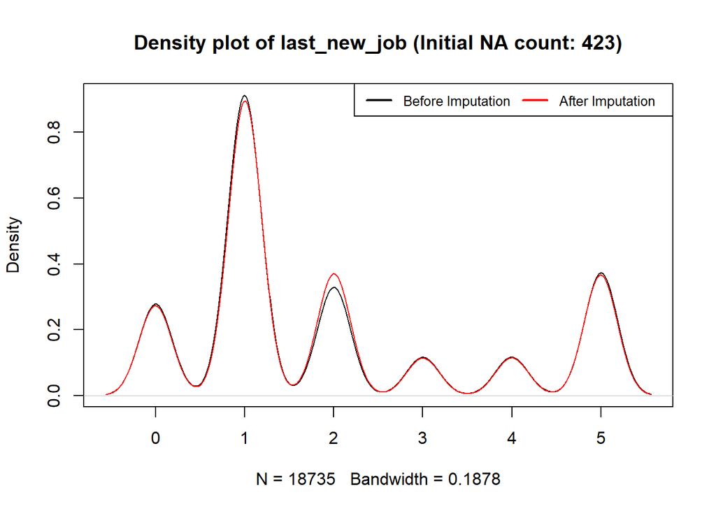

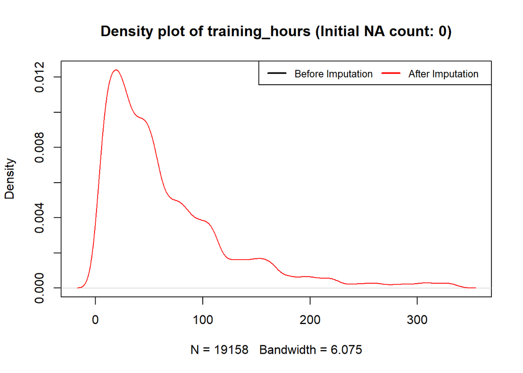

```r
# Method 1 - Imputation

# Impute continuous var (mean)
dfImputation <- df
contCol <- names(dfImputation)[sapply(dfImputation, is.numeric)]
for (col in contCol){
   sumNA <- sum(is.na(df[[col]]))
   dfImputation[ ,col][is.na(dfImputation[ ,col])] <- mean(dfImputation[ ,col], na.rm=TRUE)
   # Plot Density Plot Before & After Imputation
   plot(density(na.omit(df[[col]])),
        main=sprintf("Density plot of %s (Initial NA count: %d)", col,  sumNA))
   lines(density(dfImputation[[col]]),col="red")
   legend("topright", cex=0.8, horiz=TRUE,
          c("Before Imputation", "After Imputation"),
          lty = 1, lwd = 2, col = c("black", "red"))

}
```

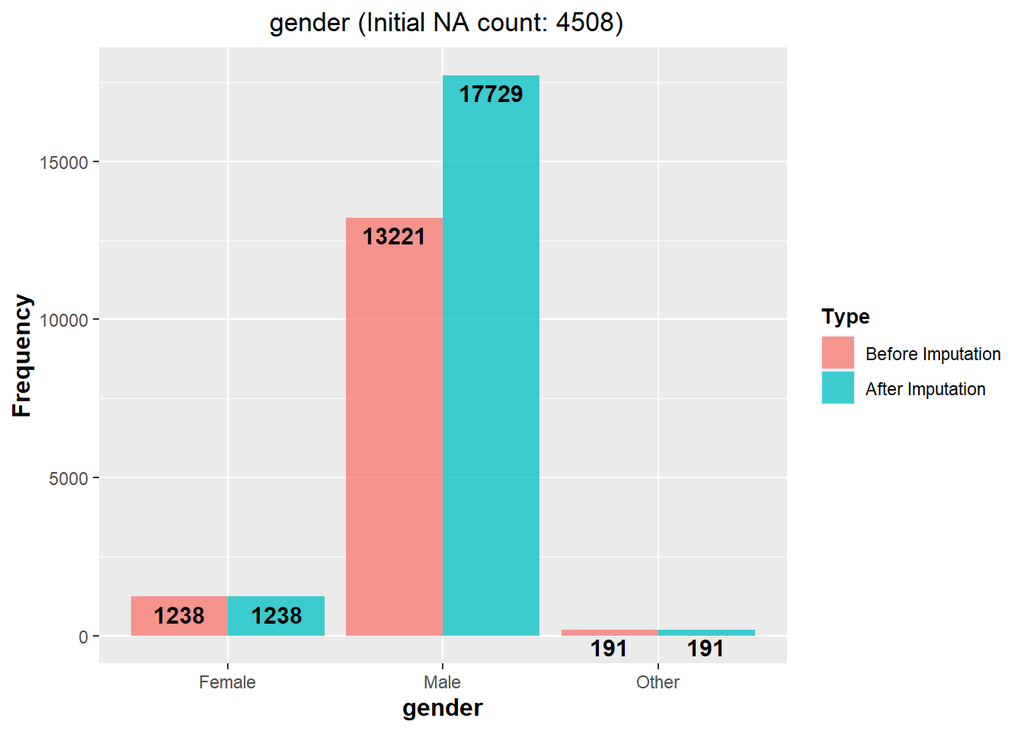

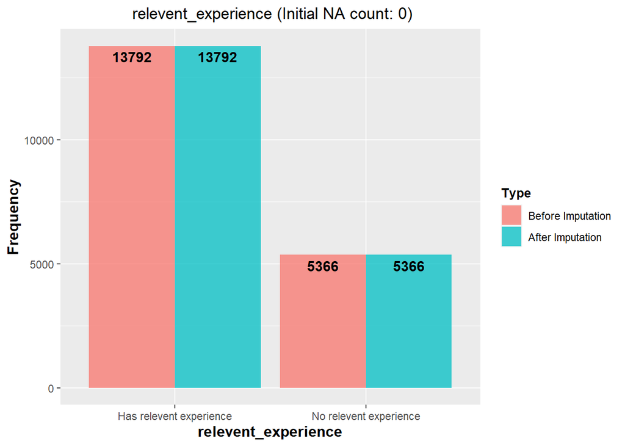

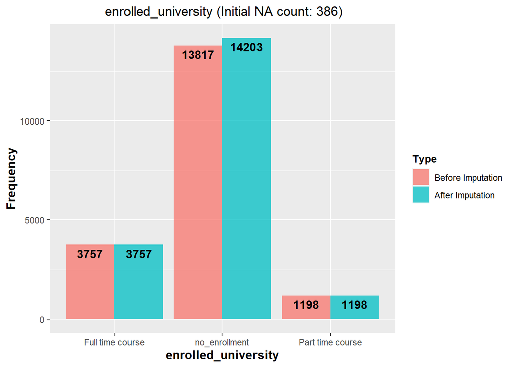

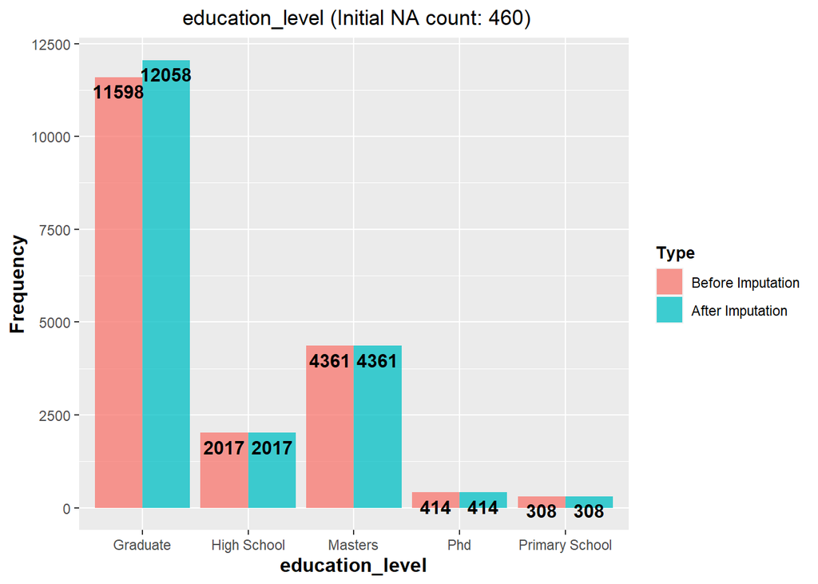

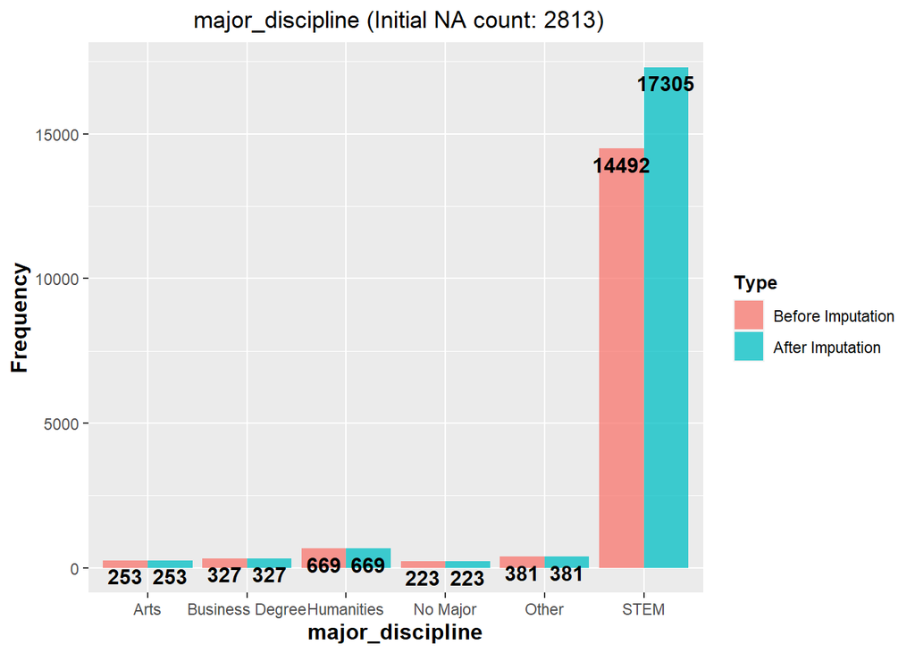

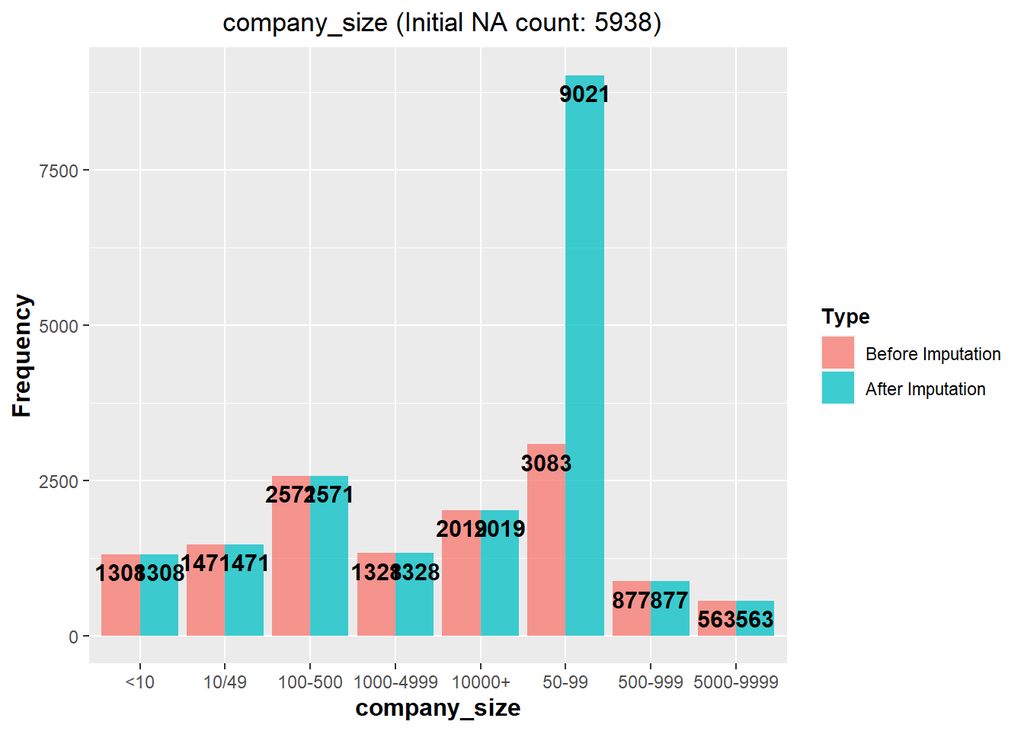

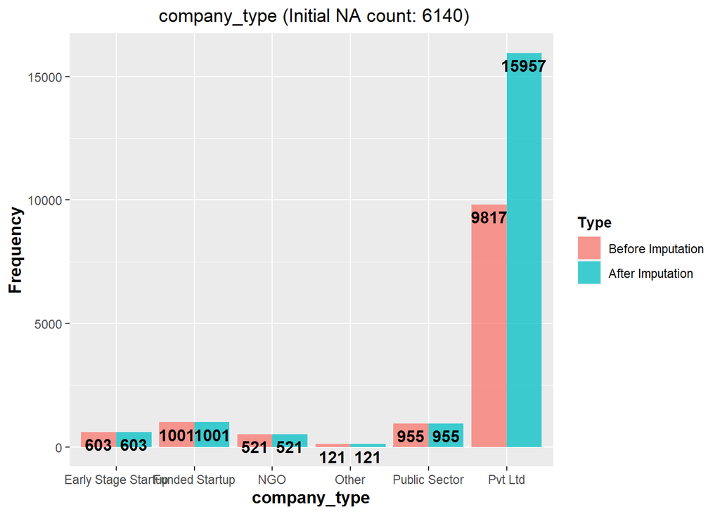

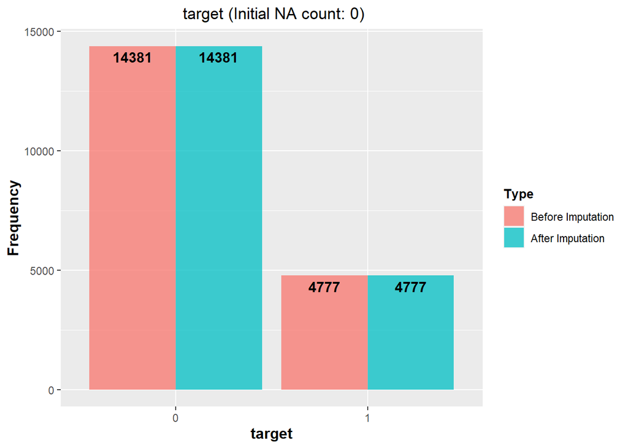

```r
# Impute factor var
facCol <- names(dfImputation)[sapply(dfImputation, is.factor)]
for (col in facCol){
   sumNA <- sum(is.na(df[[col]]))
   mode <- function(x){levels(x)[which.max(tabulate(x))]}  # Function to obtain mode
   dfImputation[ ,col][is.na(dfImputation[ ,col])] <-  mode(df[[col]])
   # Prepare data to plot graph
   colType <- c(rep("Before Imputation", dim(df)[1]),
                rep("After Imputation", dim(dfImputation)[1]))
   colVal <- c(as.character(df[,col]), as.character(dfImputation[,col]))
   outcome_data <- as.data.frame(unclass(cbind(colType, colVal)),
                                 stringsAsFactors = TRUE)
   outcome_data <- data.frame(Type = factor(colType,
                                            levels = c("Before Imputation", "After Imputation")),
                                            Category = colVal)
   # Plot side by side bar chart
   print(ggplot(data = data.frame(table(outcome_data)), aes(x = Category, y = Freq, fill = Type)) +
          geom_bar(stat = "identity", position = position_dodge(), alpha = 0.75)  +
          geom_text(aes(label = Freq), fontface = "bold", vjust = 1.5,
            position = position_dodge(.9), size = 4) +
          labs(x = col, y = "Frequency",
               title = sprintf(" %s (Initial NA count: %d)", col,  sumNA)) +
         theme(plot.title = element_text(hjust = 0.5),
               axis.title.x = element_text(face="bold", colour="black", size = 12),
               axis.title.y = element_text(face="bold", colour="black", size = 12),
               legend.title = element_text(face="bold", size = 10)))

}
```

## Method 2 - MICE

Setting: 5 iterations, cart (imputation by classification & regression trees) As MICE method takes time to run, the output is exported. (aug_train_mice.csv)

```r
# Method 2 - MICE
# mice return list, use complete() to convert to df
# df_impute_mice <- mice(df, 5, method="cart")
# df_impute_mice <- complete(df_impute_mice)
# plot_missing(df_impute_mice)
# write.csv(df_impute_mice, file = "aug_train_mice.csv")
df_impute_mice <- read.csv('aug_train_mice.csv', header = T, na.strings=c("NA","NaN", ""), stringsAsFactors=T)
```

## Method 3 - missForest

Setting: 5 iterations As missForest method takes time to run, the output is exported (aug_train_mF.csv)

```r
# Method 3 - missForest
# df_mF <- missForest(df, maxiter = 5)
# df_mF <- (df_mF$ximp)
# plot_missing(df_mF)
# write.csv(df_mF, file = "aug_train_mF.csv")
df_mF <- read.csv('aug_train_mF.csv', header = T, na.strings=c("NA","NaN", ""), stringsAsFactors=T)
```

Compare 3 methods of imputation.

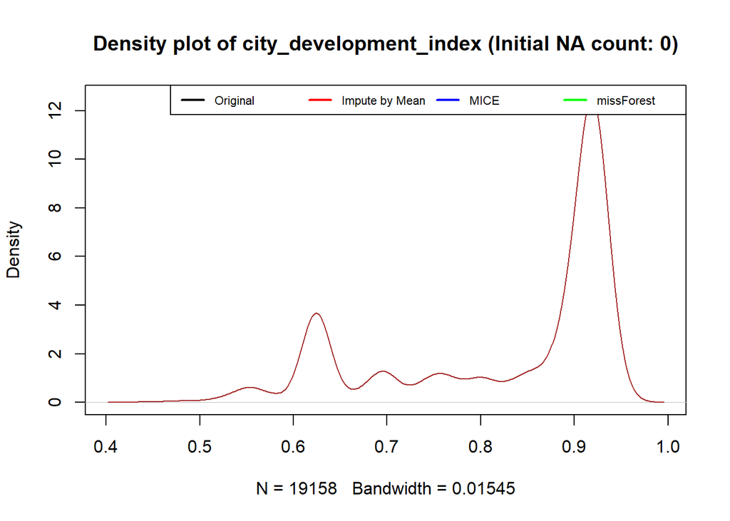

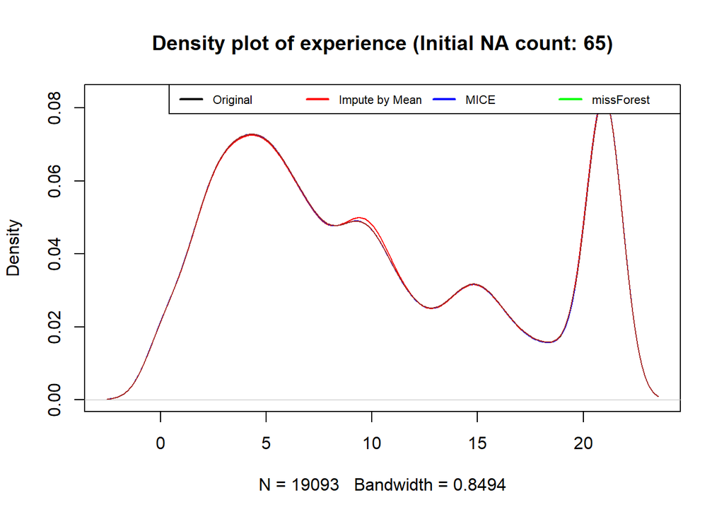

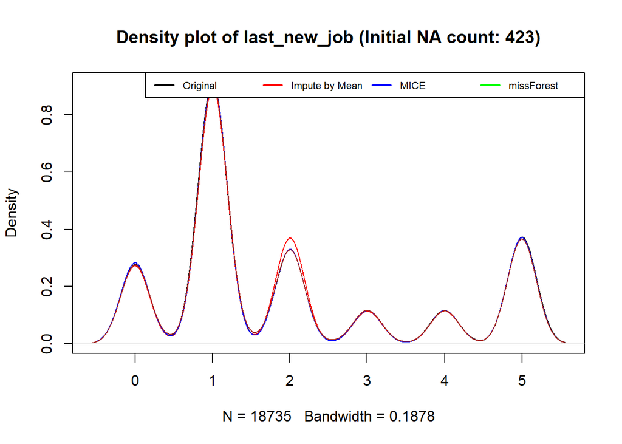

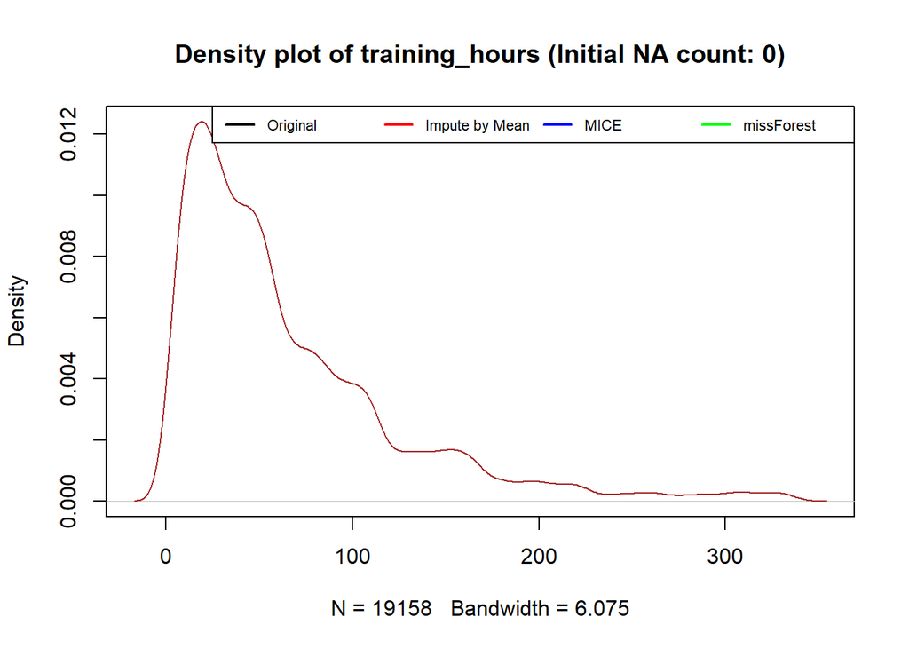

```r
# Plot graph

# Continuous Column
contCol <- names(dfImputation)[sapply(dfImputation, is.numeric)]
for (col in contCol){
   sumNA <- sum(is.na(df[[col]]))
   # Plot Density Plot Before & After Imputation
   plot(density(na.omit(df[[col]])),
        main=sprintf("Density plot of %s (Initial NA count: %d)", col,  sumNA))
   lines(density(dfImputation[[col]]),col="red")
   lines(density(df_impute_mice[[col]]),col="blue")
   lines(density(df_mF[[col]]),col="brown")
   legend("topright", cex=0.7, horiz=TRUE,
          c("Original", "Impute by Mean", "MICE", "missForest"),
          lty = 1, lwd = 2, col = c("black", "red", "blue", "green"))
}
```

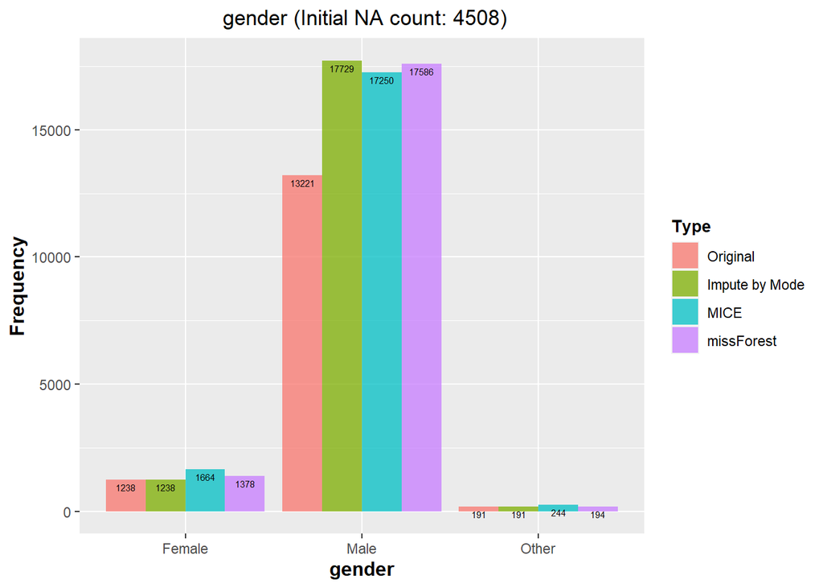

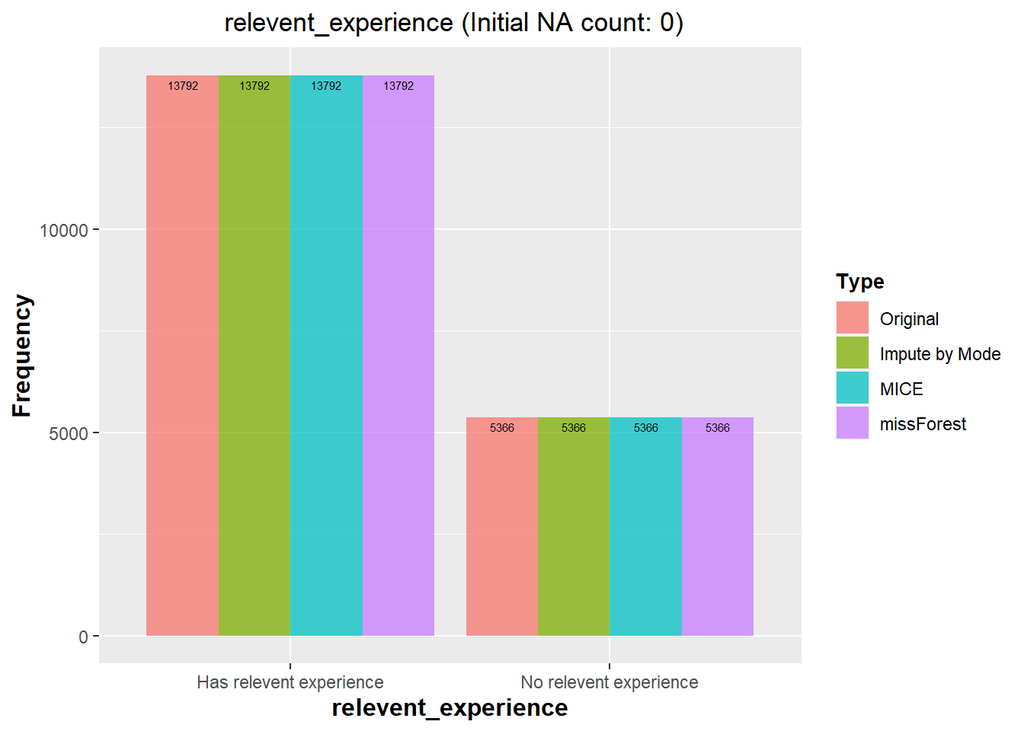

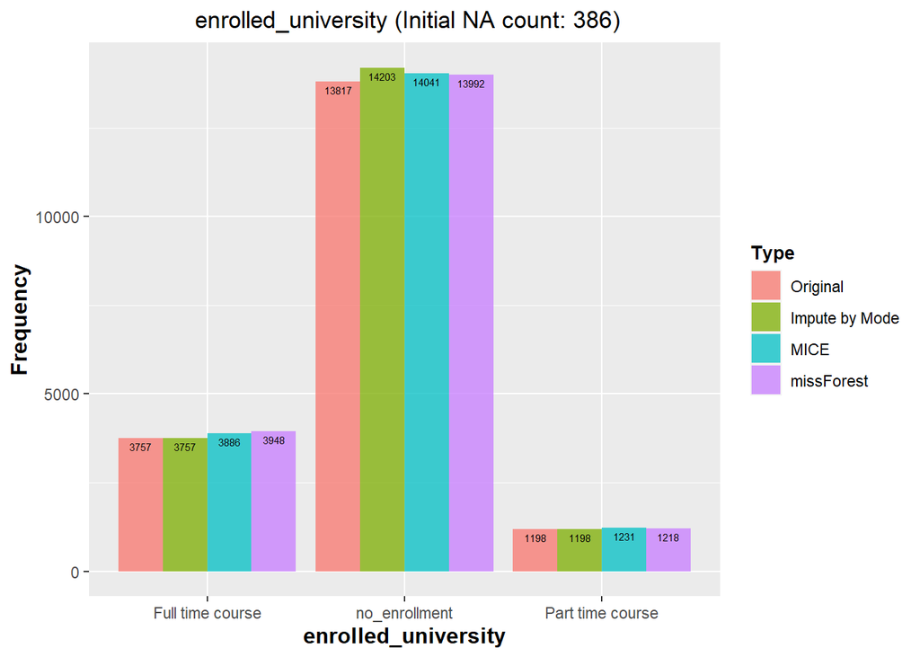

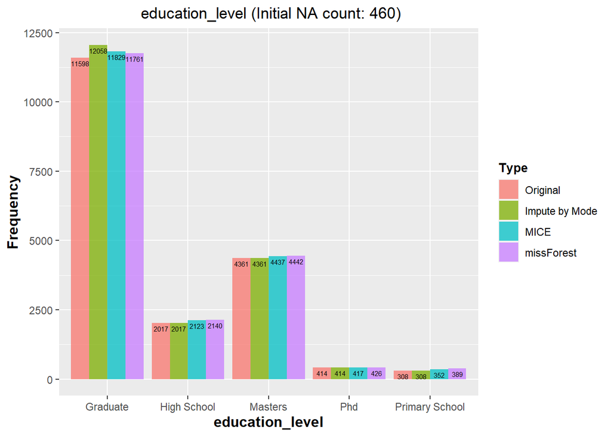

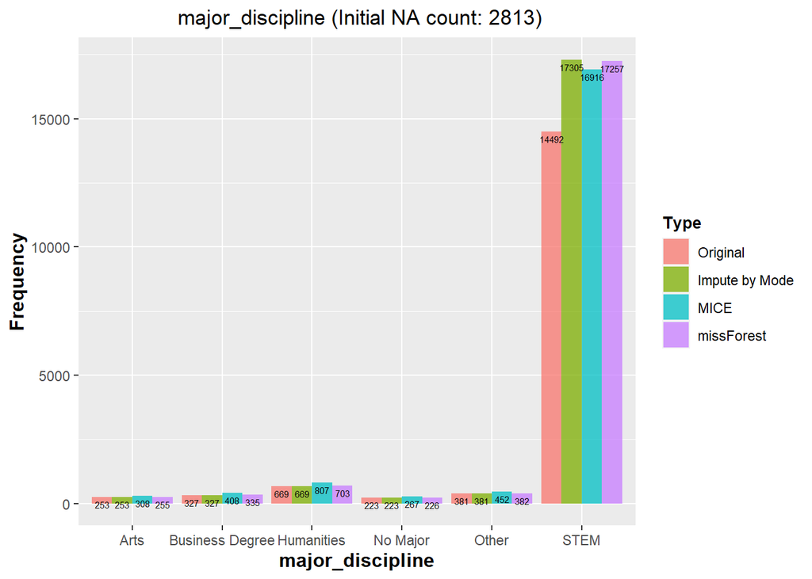

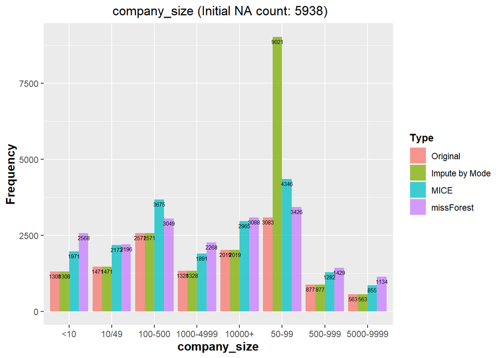

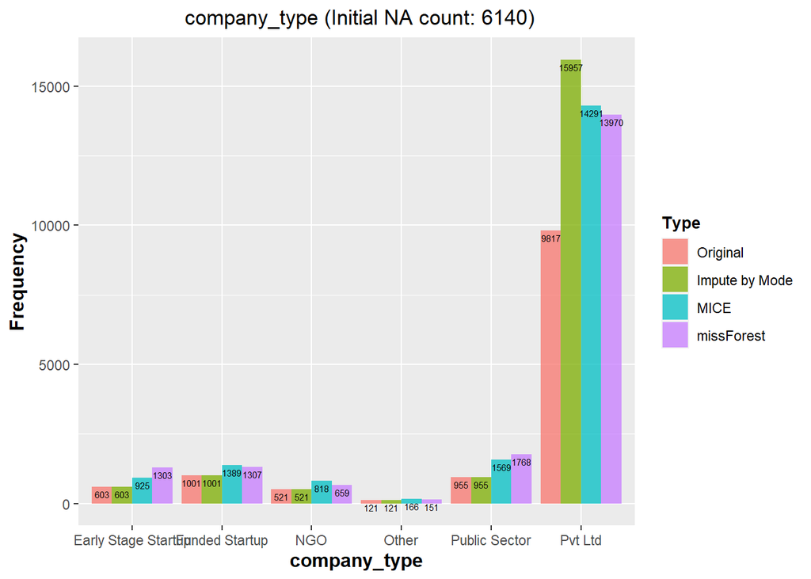

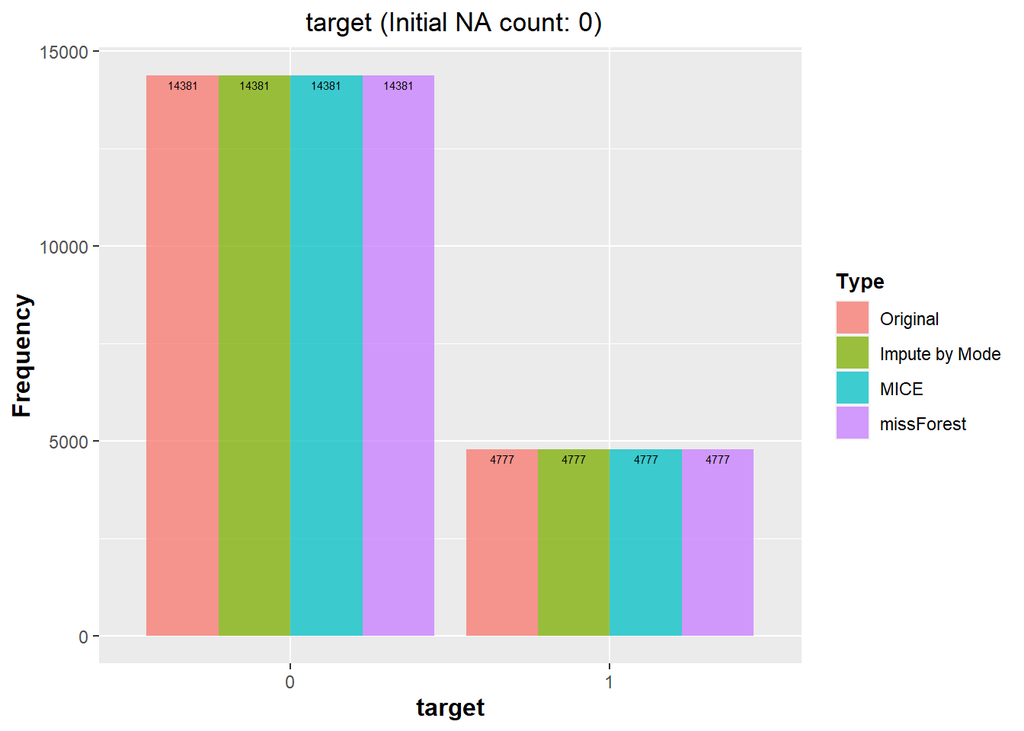

```r
# Categorical variable
# Impute factor var
facCol <- names(dfImputation)[sapply(dfImputation, is.factor)]
for (col in facCol){
   sumNA <- sum(is.na(df[[col]]))
   # Prepare data to plot graph
   colType <- c(rep("Original", dim(df)[1]),
                rep("Impute by Mode", dim(dfImputation)[1]),
                rep("MICE", dim(df_impute_mice)[1]),
                rep("missForest", dim(df_mF)[1]))
   colVal <- c(as.character(df[,col]), as.character(dfImputation[,col]),
               as.character(df_impute_mice[,col]), as.character(df_mF[,col]))
   outcome_data <- as.data.frame(unclass(cbind(colType, colVal)),
                                 stringsAsFactors = TRUE)
   outcome_data <- data.frame(Type = factor(colType,
                                            levels = c("Original", "Impute by Mode",
                                                       "MICE", "missForest")),
                                            Category = colVal)
   # Plot side by side bar chart
   print(ggplot(data = data.frame(table(outcome_data)), aes(x = Category, y = Freq, fill = Type)) +
          geom_bar(stat = "identity", position = position_dodge(), alpha = 0.75)  +
          geom_text(aes(label = Freq), vjust = 1.5,
            position = position_dodge(.9), size = 2) +
          labs(x = col, y = "Frequency",
               title = sprintf(" %s (Initial NA count: %d)", col,  sumNA)) +
         theme(plot.title = element_text(hjust = 0.5),
               axis.title.x = element_text(face="bold", colour="black", size = 12),
               axis.title.y = element_text(face="bold", colour="black", size = 12),
               legend.title = element_text(face="bold", size = 10)))
}
```

**The following will use df_impute_mice instead of the original df.

# Data Encoding

Reference: https://www.r-bloggers.com/2020/02/a-guide-to-encoding-categorical-features-using-r/ Encoding for categorical features: Nominal - One Hot Encoding Ordinal - defined order

## Encoding - Ordinal Variables

Ordinal variables: education_level, company_size

```r
ordinalCol = c("education_level", "company_size")

# Encoding for Ordinal Variable, Follow defined order
encode_ordinal <- function(x, order = unique(x)) {
  x <- as.numeric(factor(x, levels = order, exclude = NULL))
  x
}

df_impute_mice_encoded <- df_impute_mice

# Column education_level
levels(df_impute_mice_encoded$education_level)
```

```
## [1] "Graduate"       "High School"    "Masters"        "Phd"
## [5] "Primary School"
```

```r
table(df_impute_mice_encoded[["education_level"]],
      encode_ordinal(df_impute_mice_encoded[["education_level"]],
      order = c("Primary School", "High School", "Graduate", "Masters", "Phd")),
      useNA = "ifany")
```

```
##
##                      1     2     3     4     5
##   Graduate           0     0 11829     0     0
##   High School        0  2123     0     0     0
##   Masters            0     0     0  4437     0
##   Phd                0     0     0     0   417
##   Primary School   352     0     0     0     0
```

```r
# Column company_size
levels(df_impute_mice_encoded$company_size)
```

```
## [1] "<10"       "10/49"     "100-500"   "1000-4999" "10000+"    "50-99"
## [7] "500-999"   "5000-9999"
```

```r
table(df_impute_mice_encoded[["company_size"]],
      encode_ordinal(df_impute_mice_encoded[["company_size"]],
      order = c("<10", "10/49", "50-99", "100-500", "500-999",
                "1000-4999", "5000-9999", "10000+")),
      useNA = "ifany")
```

```
##
##                1    2    3    4    5    6    7    8
##   <10       1971    0    0    0    0    0    0    0
##   10/49        0 2173    0    0    0    0    0    0
##   100-500      0    0    0 3675    0    0    0    0
##   1000-4999    0    0    0    0    0 1891    0    0
##   10000+       0    0    0    0    0    0    0 2965
##   50-99        0    0 4346    0    0    0    0    0
##   500-999      0    0    0    0 1282    0    0    0
##   5000-9999    0    0    0    0    0    0  855    0
```

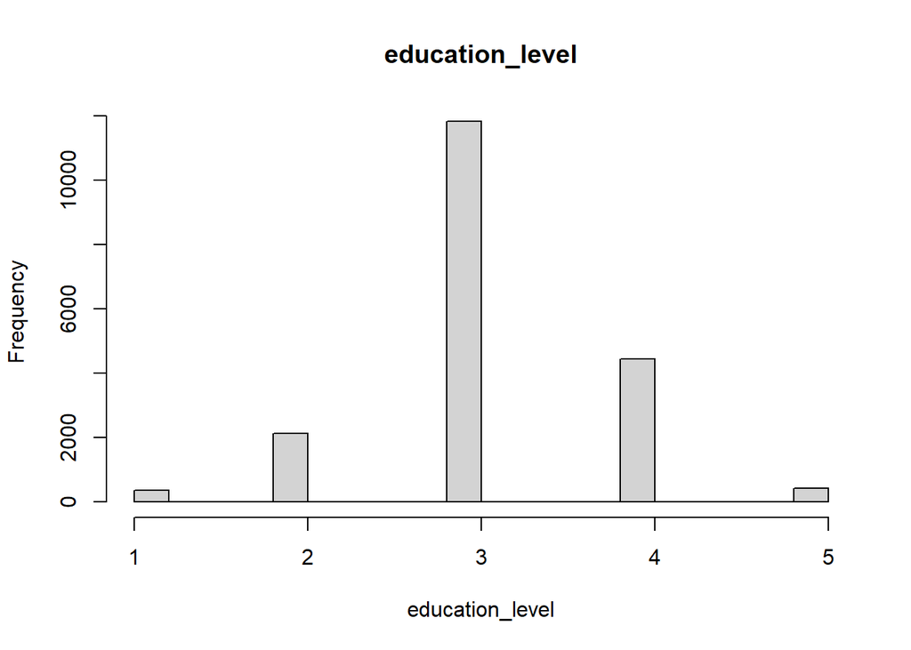

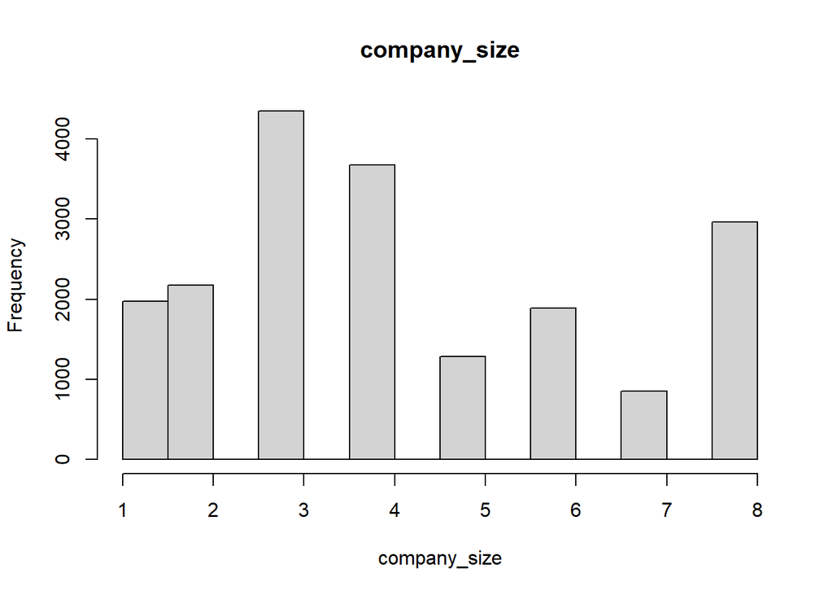

```r
# Encode the df
df_impute_mice_encoded[["education_level"]] <- encode_ordinal(df_impute_mice_encoded[["education_level"]],
               order = c("Primary School", "High School", "Graduate", "Masters", "Phd"))
df_impute_mice_encoded[["company_size"]] <- encode_ordinal(df_impute_mice_encoded[["company_size"]],
               order = c("<10", "10/49", "50-99", "100-500", "500-999",
                         "1000-4999", "5000-9999", "10000+"))

for (col in ordinalCol){
   hist((df_impute_mice_encoded[[col]]), main=col, xlab=col)
}
```

## Encoding - Nominal Variables

Nominal variables: gender, enrolled_university, major_discipline, company_type Use dummyVars from caret Package

```r
nominalCol = c("gender", "enrolled_university", "major_discipline", "company_type")
dummy <- caret::dummyVars(" ~ gender + enrolled_university + major_discipline + company_type",
                          data = df_impute_mice_encoded)
dummy <- data.frame(predict(dummy, newdata = df_impute_mice_encoded))
df_impute_mice_encoded <- cbind(subset(df_impute_mice_encoded, select=-c(gender, enrolled_university, major_discipline, company_type)), dummy)
head(df_impute_mice_encoded, 5)
```

```
##   X city_development_index     relevent_experience education_level experience
## 1 1                  0.920 Has relevent experience               3         21
## 2 2                  0.776  No relevent experience               3         15
## 3 3                  0.624  No relevent experience               3          5
## 4 4                  0.789  No relevent experience               3          0
## 5 5                  0.767 Has relevent experience               4         21
##   company_size last_new_job training_hours target gender.Female gender.Male
## 1            3            1             36      1             0           1
## 2            3            5             47      0             0           1
## 3            6            0             83      0             0           1
## 4            2            0             52      1             0           1
## 5            3            4              8      0             0           1
##   gender.Other enrolled_university.Full.time.course
## 1            0                                    0
## 2            0                                    0
```

[output cut: 39 more lines]

Other methods: 1. mutate() by own dict 2. factor(level, label) 3. onehotencoding - dummify

## Encoding - Binary

Binary category variable: relevent_experience “Has relevent experience” –> 1 “No relevent experience” –> 0

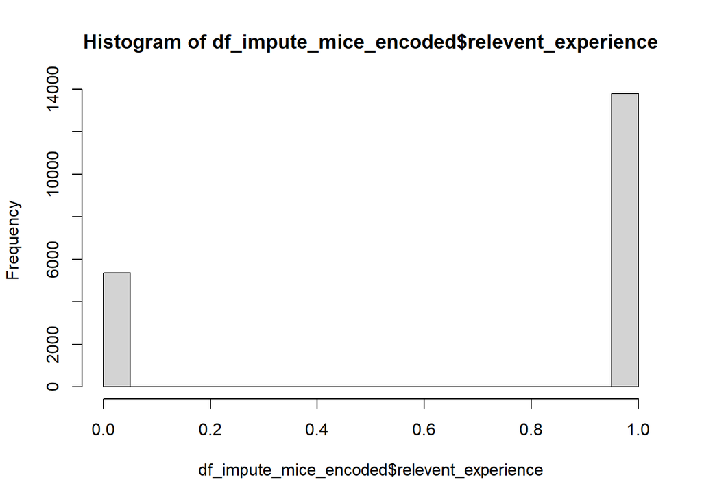

```r
levels(df_impute_mice_encoded$relevent_experience) <- c(levels(df_impute_mice_encoded$relevent_experience),"1","0")
df_impute_mice_encoded$relevent_experience[df_impute_mice_encoded$relevent_experience=="Has relevent experience"]  <- "1"
df_impute_mice_encoded$relevent_experience[df_impute_mice_encoded$relevent_experience=="No relevent experience"]  <- "0"
# Convert from factor to numeric
df_impute_mice_encoded$relevent_experience <- as.numeric(as.character(df_impute_mice_encoded$relevent_experience))
hist(df_impute_mice_encoded$relevent_experience)
```

After encoding:

```r
head(df_impute_mice_encoded, 5)
```

```
##   X city_development_index relevent_experience education_level experience
## 1 1                  0.920                   1               3         21
## 2 2                  0.776                   0               3         15
## 3 3                  0.624                   0               3          5
## 4 4                  0.789                   0               3          0
## 5 5                  0.767                   1               4         21
##   company_size last_new_job training_hours target gender.Female gender.Male
## 1            3            1             36      1             0           1
## 2            3            5             47      0             0           1
## 3            6            0             83      0             0           1
## 4            2            0             52      1             0           1
## 5            3            4              8      0             0           1
##   gender.Other enrolled_university.Full.time.course
## 1            0                                    0
## 2            0                                    0
```

[output cut: 39 more lines]

```r
write.csv(df_impute_mice_encoded, file = "aug_train_mice_encoded.csv")
```